# Datos de series de tiempo

# Análisis gráfico

A continuación se mostrará como cargar los datos de la base “dvds” y “termostatos”, ambas bases son ventas trimestrales de estos productos. A diferencia de la base “bacalao” estos datos son trimestrales en vez de anuales, la forma de declarar los datos como serie de tiempo cambia.

Establecemos el directorio de trabajo:

```r
setwd("C:/Users/Miike/Desktop/Pronosticos/suavizacion")
```

limpio mi ambiente de trabajo y cargo las librerias, **ahora añado la libreria “lubridate”** para manipular variables de fecha, antes de cargar la libreria verifica que ya fue instalada, de lo contrario, instala primero la libreria:

```r
rm(list=ls())

library(readr)
library(forecast)
library(tidyverse)
library(lubridate)
```

cargo los datos en tres objetos:

```r
datos_pesca <- read_csv("bacalao.csv")

ventas_termostatos <- read_csv("termostatos.csv")

ventas_dvds <- read_csv("dvds.csv")
```

### Datos de bacalao

Estos datos son anuales, la base datos contiene dos variables, uso la función *glimpse()* para ver el contenido de un objeto y el tipo variables que son, en este caso, observo que del objeto *datos_pesca*, contiene una variable que se llama *periodo*, la cual la es numerica (num) y la variable *pesca* también es numérica (num):

```r
glimpse(datos_pesca)
```

```
## Rows: 24
## Columns: 2
## $ periodo <dbl> 1995, 1996, 1997, 1998, 1999, 2000, 2001, 2002, 2003, 2004, 20~
## $ pesca   <dbl> 362, 381, 317, 297, 399, 402, 375, 349, 386, 328, 389, 343, 27~
```

Para graficar la serie junto con la media, y más, menos dos desviaciones estándar, usamos la función *ggplot()*, la cual se construye con capas:

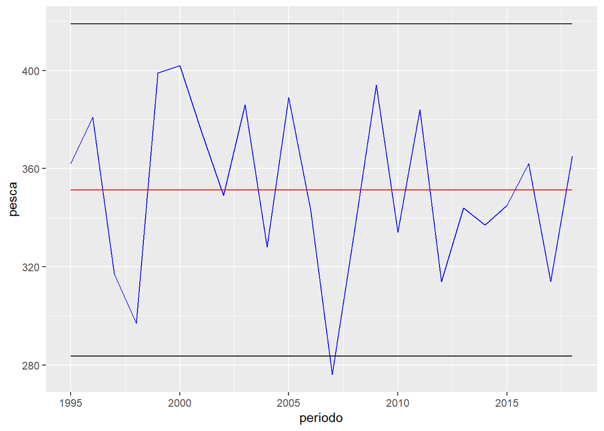

```r
ggplot(datos_pesca, aes(x=periodo)) +
  geom_line(aes (y=pesca), colour="blue") +
  geom_line(aes (y=mean(pesca)), colour="red" ) +
  geom_line(aes (y=mean(pesca)+2*sd(pesca) )) +
  geom_line(aes (y=mean(pesca)-2*sd(pesca) ))
```

### Datos de termostatos

Para poder realizar una gráfica como la anterior, necesito tener una variable de fecha, nota que el objeto *ventas_termostatos* contiene dos variables, una llamada “periodo”, la cuál es una variable de una variable de texto (chr) y ventas es numérica:

```r
glimpse(ventas_termostatos)
```

```
## Rows: 52
## Columns: 2
## $ periodo <chr> "2009 Q1", "2009 Q2", "2009 Q3", "2009 Q4", "2010 Q1", "2010 Q~
## $ ventas  <dbl> 206, 245, 185, 169, 162, 177, 207, 216, 193, 230, 212, 192, 16~
```

Para generar una nueva variable utilizamos la función *mutate()* y la función *yq()*, la cual sirve transformar una variable de texto que representa una fecha a una variable de tiempo, la función *yq()* busca una variable que primerio indique el año y posteriormente el trimestre, tal como están nuestros datos:

```r
ventas_termostatos <- ventas_termostatos %>%
  mutate(periodo=yq(periodo))
```

Nota que ahora la variable periodo es una variable de fecha (Date):

```r
glimpse(ventas_termostatos)
```

```
## Rows: 52
## Columns: 2
## $ periodo <date> 2009-01-01, 2009-04-01, 2009-07-01, 2009-10-01, 2010-01-01, 2~
## $ ventas  <dbl> 206, 245, 185, 169, 162, 177, 207, 216, 193, 230, 212, 192, 16~
```

Después de este punto ya podemos realizar una gráfica de la serie junto con la media, y más, menos dos desviaciones estándar, usamos la función *ggplot()*

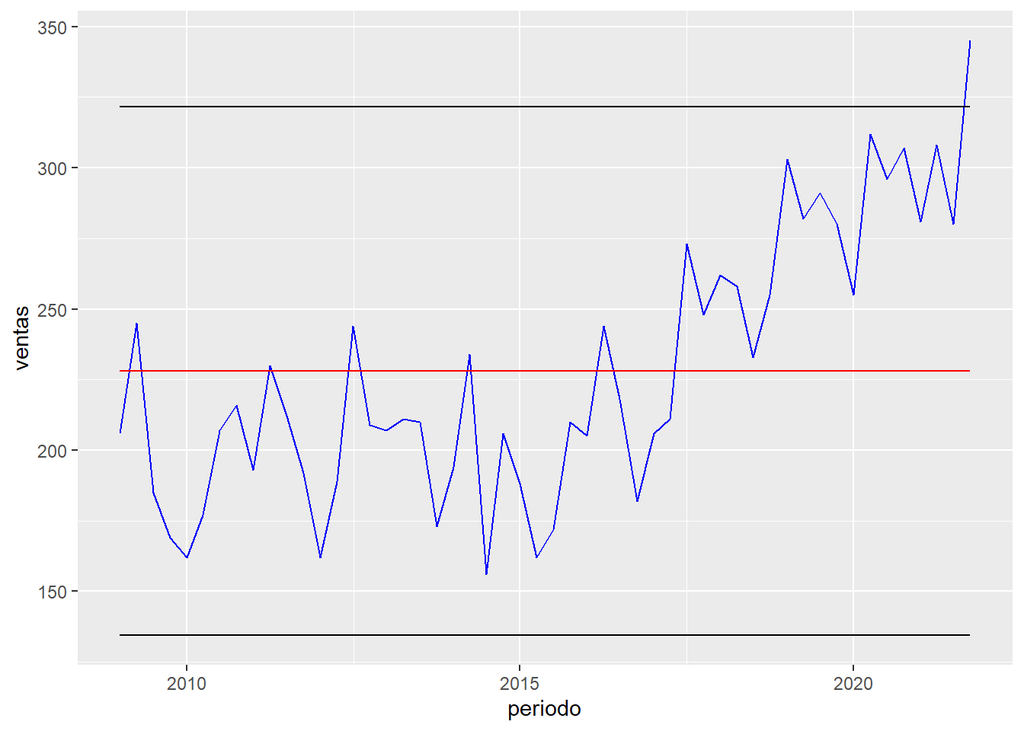

```r
ggplot(ventas_termostatos, aes(x=periodo)) +
  geom_line(aes (y=ventas), colour="blue") +
  geom_line(aes (y=mean(ventas)), colour="red" ) +
  geom_line(aes (y=mean(ventas)+2*sd(ventas) )) +
  geom_line(aes (y=mean(ventas)-2*sd(ventas) ))
```

### Datos de Dvd’s

Algo similar sucede con esta serie, la variable de periodo es texto, necesitamos reemplazar esta variable con una variable de tiempo:

```r
glimpse(ventas_dvds)
```

```
## Rows: 33
## Columns: 2
## $ periodo <chr> "1998 Q1", "1998 Q2", "1998 Q3", "1998 Q4", "1999 Q1", "1999 Q~
## $ ventas  <dbl> 45.9, 31.9, 40.3, 38.4, 34.5, 25.9, 34.8, 41.2, 38.0, 41.8, 41~
```

hacemos el cambio:

```r
ventas_dvds <- ventas_dvds %>%
  mutate(periodo=yq(periodo))
```

Después de esto ya podemos generar la gráfica usando la función ggplot.

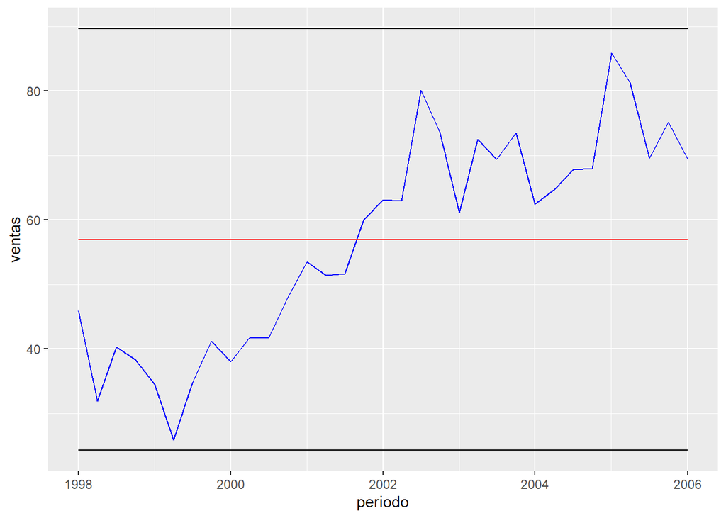

```r
ggplot(ventas_dvds, aes(x=periodo)) +
  geom_line(aes (y=ventas), colour="blue") +
  geom_line(aes (y=mean(ventas)), colour="red" ) +
  geom_line(aes (y=mean(ventas)+2*sd(ventas) )) +
  geom_line(aes (y=mean(ventas)-2*sd(ventas) ))
```

# Objeto de serie de tiempo

Para utilizar las funciones de pronósticos, **R** debe saber que los datos que vamos utilizar son una serie de tiempo, es decir, necesitamos declarar que es una serie de tiempo, para ello usamos la función *ts()* indicando el periodo de inicio y la frecuencia tal como se muestra a continuación:

## Datos anuales

Datos anuales desde 1995:

```r
bacalao <- ts(datos_pesca$pesca, start=1995, frequency=1)
```

## Datos trimestrales

Datos trimestrales desde el primer trimestre de 2009

```r
termostatos <- ts(ventas_termostatos$ventas, start = c(2009,1), frequency=4)
```

Datos trimestrales desde el primer trimestre de 1998

```r
dvds <- ts(ventas_dvds$ventas, start=c(1998,1), frequency = 4)
```